# 幻をサンプリングする

吸血鬼を$95\%$の正確さで検出する血液検査があると仮定する（すなわち，$P(positive | vampire) = 0.95$）。しかし，$1\%$の確率で健常者を誤って吸血鬼と診断してしまう（いわゆる偽陽性で，$P(positive | normal) = 0.01$）。吸血鬼は全人口の$0.1\%$しかいない（$P(vampire) = 0.001$）。検査を受けたある人が陽性判定を受けた。この人が吸血鬼である確率は，ベイズの定理から約$8.7\%$と計算できる。

$$\begin{eqnarray*}
P(vampire | positive) &=& \frac{P(positive | vampire) P(vampire)}{P(positve)} \\
&=& \frac{P(positive | vampire) P(vampire)}{P(positive | vampire) P(vampire) + P(positive | normal) P(normal)}
\end{eqnarray*}$$

```r
PrPV = 0.95
PrPM = 0.01
PrV = 0.001
PrP = PrPV * PrV + PrPM * (1 - PrV)
(PrVP = PrPV * PrV / PrP)
```

```
## [1] 0.08683729
```

関心の点が非常に稀である時，陽性の大部分は偽陽性となる。しかし，ベイズ統計でよく用いられるこういった例は$2つ$の理由で適切ではない。第一に，「ベイジアン」はベイズの定理の使用によってではなく，確率に関する広い視座によって区別されるべきである。上記の例での使用は，どんな統計家でも反対しない。第二に，こういった例はベイズ推論を必要以上に難しく思わせてしまう。どの数値をどこに当てはめるか，ほとんどの人にとってはその手続きの理屈がつかめない。

しかし，同じ問題をより直感的に表現する方法（度数形式 frequency format）がある。

1. 全人口が$100,000$人だとすると，$100$人が吸血鬼である。
2. $100$人の吸血鬼のうち$95$人が陽性判断を受ける。
3. $99,900$人の健常者のうち$999$人が陽性判断を受ける。

陽性判断を受けた人は$95+999=1094$人であり，このうち$95$人が本物の吸血鬼であるから，

$$P(vampire | positive) = \frac{95}{1094} \approx 0.087$$

と，定理を使わずに同じ解に到達できる。

なぜ度数形式が直感的に正解に導きやすいかはよく分かっていないが，日常生活では確率よりも数え上げの方が馴染みがあり，人間心理がうまく働くのだろう。確率分布そのものよりも，そこからのサンプリングはイメージできる。ほとんどのパラメータの正確な実在は経験できない。しかし，コンピュータ内部ではパラメータはコイントス同様経験的である。事後分布はパラメータ値の期待度数と考えると把握しやすい。

多くの科学者は積分が苦手である。サンプリングは積分の問題をデータ要約の問題に変換してくれる。サンプリングによる現代的アプローチがMCMCであり，もはや専門家だけの手法ではなくなり，数量的な科学における標準的ツールとなっている。

蛇足として，帰無仮説有意性検定をベイズの定理から考えよう。仮説が真である時，それに対する陽性判断が下される「検定力（power）」の確率が$0.95$であるとする（すなわち，$P(positive | true) = 0.95$）。また，仮説が偽である時，それに対する陽性判断が下される確率を$0.05$とする（すなわち，$P(positive | false) = 0.05$）。これはいわゆる$5\%有意水準$であり，偽陽性のことである。仮説が真である確率$P(true)$は誰にも分からないが，科学の歴史はそれが小さいことを暗示している。ここでは仮に$P(true) = 0.01$とおく。ベイズの定理から，$P(true | positive) \approx 0.16$である。また，偽陽性の確率（有意水準）を$1\%$にすると，事後確率は$0.5$に近くなる。

```r
PrPT = 0.95
PrPF = c(0.05, 0.01)
PrT = 0.01
(PrTP = (PrPT * PrT) / (PrPT * PrT + PrPF * (1 - PrT)))
```

```
## [1] 0.1610169 0.4896907
```

最重要課題は基礎確率$P(true)$を高めることであり，そのために必要なのは考えることである。検定ではない。

# 3.1. グリッド近似による事後分布からのサンプリング

地球儀問題でのグリッド近似は以下のようなRスクリプトであった。

```r
p_grid = seq(from = 0, to = 1, length.out = 1000)
prior = rep(1 , 1000)
likelihood = dbinom(6, size = 9, prob = p_grid)
unstandardized.posterior = likelihood * prior
posterior = unstandardized.posterior / sum(unstandardized.posterior)
```

事後分布から$10,000$個サンプリングしたいとしよう。事後分布は各パラメータ値が入ったバケツみたいなものである。つまり，各値が事後分布が定める割合でバケツに入っていて，ここから $10,000$個のパラメータ値を取り出す。

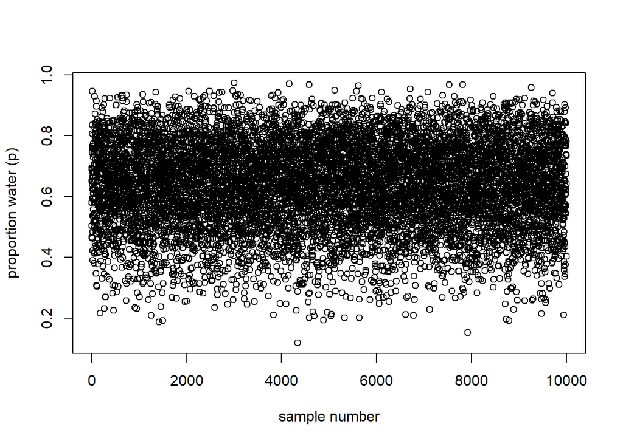

```r
samples = sample(p_grid, prob = posterior, size = 1e4, replace = TRUE)
plot(samples, xlab = "sample number", ylab = "proportion water (p)")
```

$p = 0.6$付近にサンプルは密集しており，$p \le 0.25$ではサンプルはほとんどない。推定される事後分布の概形は，グリッド近似で計算したものとよく似ている（Figure 3.1またはRの出力参照。但し，これらのサンプルは異なるものに基づいている）。

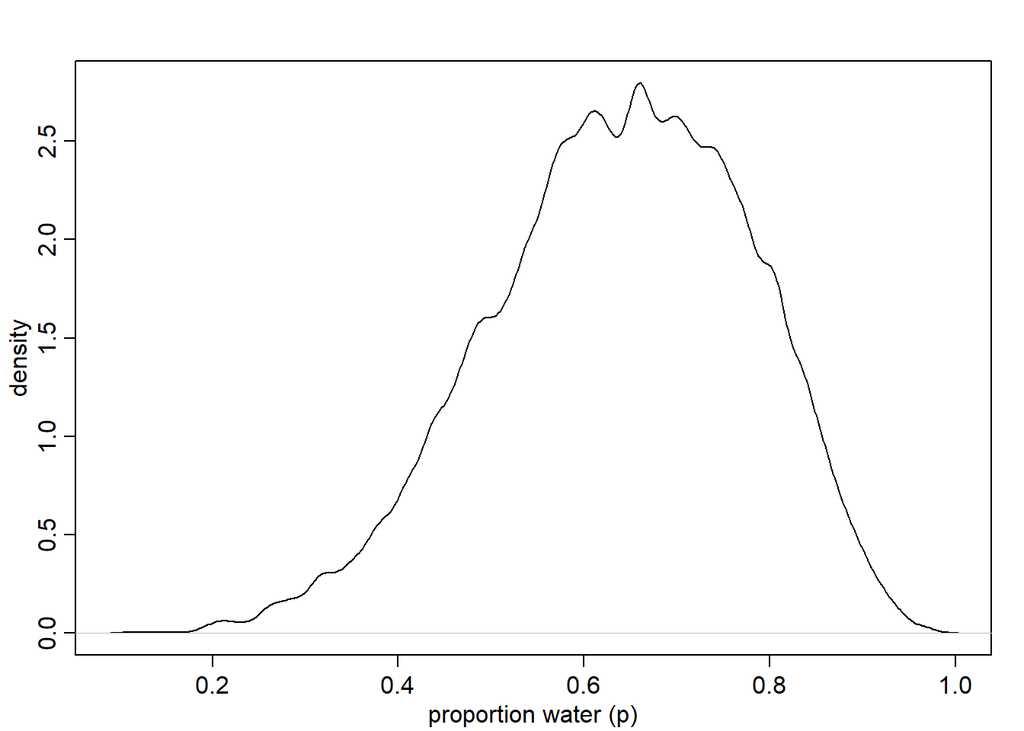

```r
# library(rethinking)
dens(samples, xlab = "proportion water (p)", ylab = "density")
```

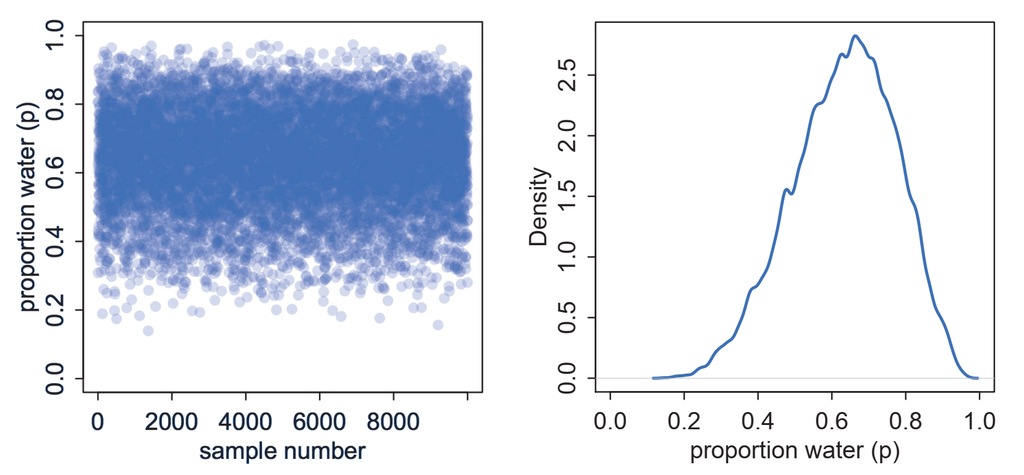

Figure 3.1

サンプリングする数を増やせば増やすほど，密度推定はどんどん似てくる。

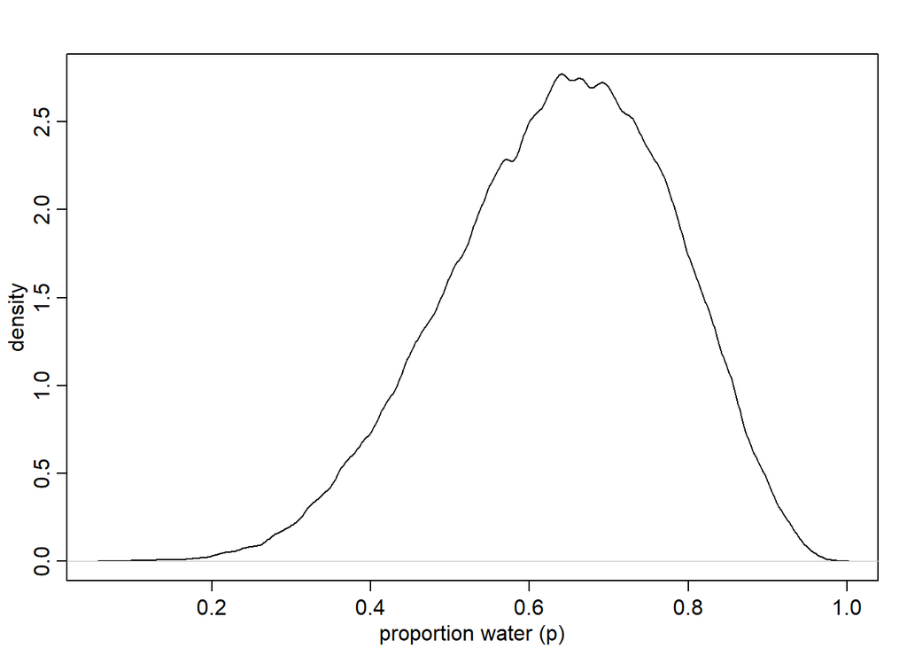

```r
samples.1e5 = sample(p_grid, prob = posterior, size = 1e5, replace = TRUE)
dens(samples.1e5, xlab = "proportion water (p)", ylab = "density")
```

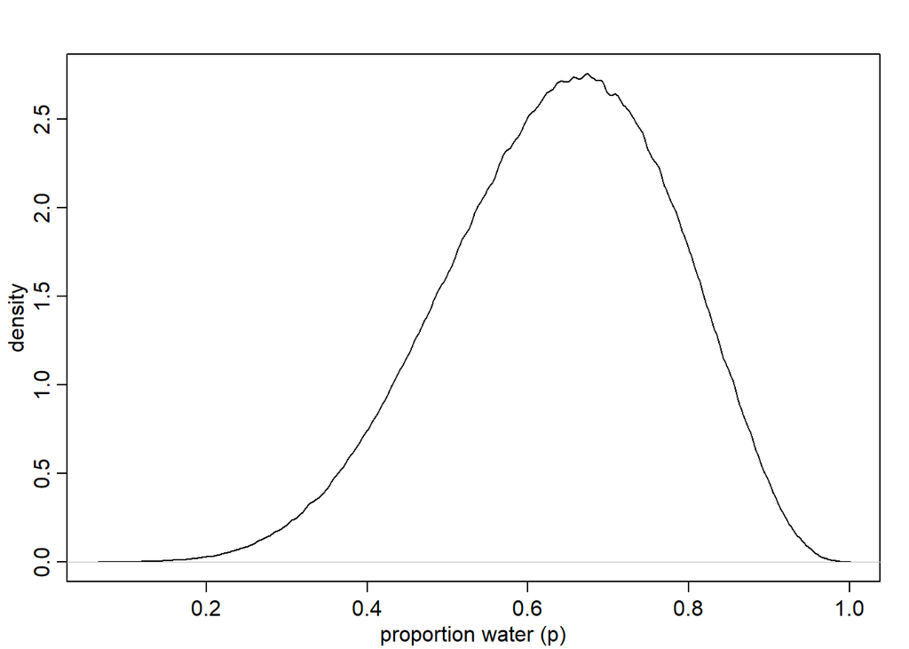

```r
samples.1e6 = sample(p_grid, prob = posterior, size = 1e6, replace = TRUE)
dens(samples.1e6, xlab = "proportion water (p)", ylab = "density")
```

# 3.2. 要約のためのサンプリング

目的次第ではあるが，事後分布の要約や解釈を行う。オーソドックスな問いは次のようなものである：

- あるパラメータ値以下の事後確率は？
- $2$つのパラメータ値間の事後確率は？
- 事後確率が$5\%$以下になるパラメータ値はいくつか？
- 事後確率の$90\%$を含むパラメータ値の範囲は？
- 事後確率が最大となるパラメータ値はいくつか？

これらの問いは内容から次のように分類できる。

1. 境界（boundaries）
2. 確率質量（probability mass）
3. 点推定（point estimate）

## 3.2.1. 境界

水の割合が$0.5$未満である事後確率はいくらだろうか？

```r
sum(posterior[p_grid < 0.5])
```

```
## [1] 0.1718746
```

パラメータが$1$つである地球儀問題だから簡単に感じるのであって，パラメータが多いとグリッド近似は実用性に欠ける。

事後分布からのサンプリングデータから同じ計算を行うには，次のようにする。

```r
mean(samples < 0.5)   # またはsum(samples < 0.5) / 1e4
```

```
## [1] 0.1711
```

グリッド近似での結果に近いが，サンプリングデータは同じとは限らないので，シミュレーションごとに異なる値になる。同じやり方で$0.5$から$0.75$での事後確率が計算できる。

```r
mean(samples > 0.5 & samples < 0.75)    # またはsum(samples > 0.5 & samples < 0.75) / 1e4
```

```
## [1] 0.6014
```

ここで計算した区間の確率はFigure 3.2上段に示された領域を反映している。

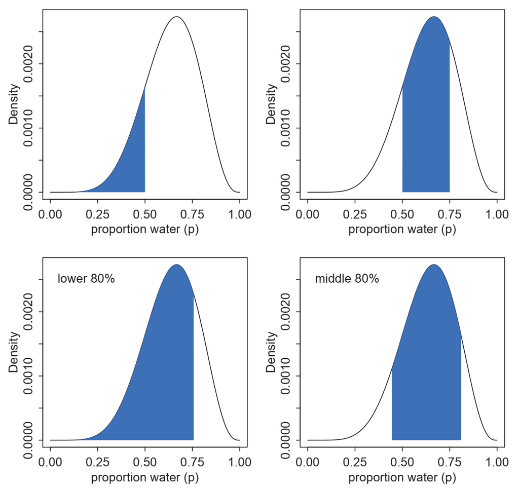

Figure 3.2

## 3.2.2. 確率質量

いわゆる信頼区間（confidence interval）や，事後分布における信用区間（credible intervalまたはベイズ信頼区間）は，特定の確率（確率質量）を含む$2$つのパラメータ値を示す要約方法である。区間推定は，グリッド近似よりもサンプリングを用いる方が容易である。例えば，下側$80\%$となる境界値を求めることは，$80$パーセンタイルを求めることと同じである。

```r
quantile(samples, 0.8)
```

```
##       80%
## 0.7627628
```

同様に中央$80\%$区間は，$10$パーセンタイルと$90$パーセンタイルを求めれば良い。

```r
quantile(samples, c(0.1 , 0.9))
```

```
##       10%       90%
## 0.4504505 0.8118118
```

これらの領域はFigure 3.2下段に示されている。

このように，分布の両裾に等しい確率を割り当てて定める区間をパーセンタイル区間（PI）と呼ぶ。今，地球儀を$3$回トスしたところ，$3$回とも「海」となったとする。事後分布は$p=1$でピークとなる非常に歪んだ分布となる。

```r
p_grid = seq(from = 0, to = 1, length.out = 1000)
prior = rep(1, 1000)
likelihood = dbinom(3, size = 3, prob = p_grid)
unstandardized.posterior = likelihood * prior
posterior = unstandardized.posterior / sum(unstandardized.posterior)
samples = sample(p_grid, size = 1e4, replace = TRUE, prob = posterior)
quantile(samples, c(0.25, 0.75))
```

```
##       25%       75%
## 0.7027027 0.9309309
```

rethinkパッケージのPI関数も同じ結果を返す。

```r
# library(rethink)
PI(samples, prob = 0.5)
```

```
##       25%       75%
## 0.7027027 0.9309309
```

Figure 3.3左はPIの領域を示す。

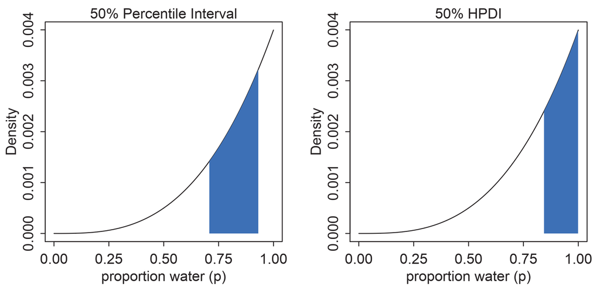

Figure 3.3

しかし，PIはピークを含めない場合がある。ピークを必ず含むようにする場合は最高事後密度区間（highest posterior density interval, HPDI）を用いる（Figure 3.3右）。

```r
# library(rethink)
HPDI(samples, prob = 0.5)
```

```
##      |0.5      0.5|
## 0.8368368 1.0000000
```

もし区間の選択によって推論結果が異なるような場合は，事後分布全体をプロットした方が良い。

自然科学や社会科学では$95\%$区間が一般的である。これは統計的有意性での伝統的な閾値（$5\%$あるいは$p<0.05$）でもある。慣習以外に正当化することは容易ではない。Fisher自身も後年には有意性のためにいつも同じ閾値を使うことには反対している。大事なのは，事後分布の概形を説明するのに十分な区間であることである。

また，非ベイズ統計学においては，区間推定に関する解釈がやや面倒である。「真のパラメータがその区間に含まれる確率が$95%である」というベイズ的な言い方は正しくない。というのも，非ベイズ統計学ではパラメータの不確実さを測るために確率を用いることは厳禁だからである。そうではなく「もし同じ測定・分析を何度も繰り返せば，計算された区間の%95%が真のパラメータを含んでいる」と言うべきである。

ただ，いずれの解釈を用いようとも，$95\%$区間は真の値を$95\%$含んでいない。信頼区間は「慢性的な過信（chronic overconfidence）」であることは科学史が物語っている。$95%$というのはスモールワールドでの数であり，その論理的世界においてのみ真である。

## 3.2.3. 点推定

ベイジアンのパラメータ推定は事後分布全体であり，単一の数ではない。しかし，点推定をしなけれならないとすると，問うべきことが出てくる。$3$回中$3$回「海」だった地球儀実験を考えよう。よく用いられる点推定量はMAP（maximum a posteriori）である。これは事後確率が最大となるパラメータ値である。いわゆるモードである。

```r
p_grid[which.max(posterior)]
```

```
## [1] 1
```

または，事後分布からのサンプルからもMAPを近似的に求めることができる。

```r
chainmode(samples, adj = 0.01)
```

```
## [1] 0.9935174
```

事後分布の平均値も中央値も点推定量であるのになぜMAPなのか？ Figure 3.4左は各点推定量の位置である。

```r
mean(samples)
```

```
## [1] 0.796026
```

```r
median(samples)
```

```
## [1] 0.8368368
```

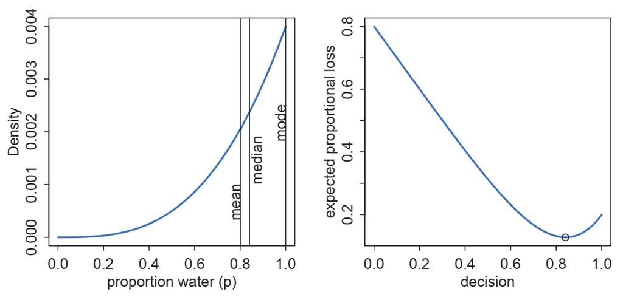

Figure 3.4

鍵となるのは損失関数（loss function）という考え方である。海の割合$p$を言い当てられたら$100$ドルがもらえるとしよう。しかし，予想と正解のズレ$|d-p|$に比例して賞金が減額される。期待される賞金を最大にする（損失を最小にする）事後分布からの点推定量は何か？ 該当するのは中央値であることが知られている。

ここでは解析的にではなく，事後分布を使って計算してみよう。仮に$p=0.5$と予想したとすると，期待損失は次のように計算される。

```r
sum(abs(0.5 - p_grid) * posterior)
```

```
## [1] 0.3128752
```

これと同じ計算を各$p$に対して行い，期待損失が最小になる$p$を求めれば良い。

```r
loss = sapply(p_grid, function(d) sum(abs(d - p_grid) * posterior))
p_grid[which.min(loss)]
```

```
## [1] 0.8408408
```

この値は中央値である。サンプリング次第では同じ値にならないかもしれないが，必ず近い値になる。

別の損失関数を使えば，別の点推定量が候補となる。$|d-p|$ではなく二次損失$(d-p)^2$を採用すれば事後平均が点推定量となる。

```r
loss = sapply(p_grid, function(d) sum((d - p_grid)^2 * posterior))
p_grid[which.min(loss)]
```

```
## [1] 0.8008008
```

しかし，応用においては特定の損失関数が要求される場合もある。例えば，台風の風速と損害に関する損失関数は，風速が増えれば損害も増えるような非対称な関数になると考えられる。このような場合，最適な点推定量は事後平均や事後中央値よりも大きくなる傾向がある。

# 3.3. 予測シミュレーションのためのサンプリング

事後分布からのデータ生成の有用性は以下の通り：

1. モデルチェック
2. プログラム検証
3. 研究デザインの評価（検定力分析を含む）
4. 予測

## 3.3.1. ダミーデータ

シミュレーションによって生成されたデータをダミーデータと呼ぶ。地球儀問題では，ダミーデータは二項分布から生成される。

$$P(w|n, p) = \frac{n!}{w!(n-w)!}p^w (1-p)^{n-w}$$

地球儀を$2$回トスすれば（$n=2$），「海」が$0$回，$1$回，$2$回のいずれかが観察される。$p=0.7$として，それぞれの尤度を計算してみる。

```r
dbinom(0:2, size = 2, prob = 0.7)
```

```
## [1] 0.09 0.42 0.49
```

次に同じ設定で，$10$回シミュレーションし，「海」のダミーデータを生成してみる。

```r
rbinom(10, size = 2, prob = 0.7)
```

```
##  [1] 1 2 1 2 0 2 2 1 2 2
```

本格的に$100,000$個のダミーデータを生成してみよう。先ほどのdbinomの結果に近いことが分かる。

```r
dummy_w = rbinom(1e5, size = 2, prob = 0.7)
table(dummy_w) / 1e5
```

```
## dummy_w
##       0       1       2
## 0.08856 0.42018 0.49126
```

当然，トス$2$回のみというのはサンプルとして十分でないので，$9$回にしてシミュレートしてみよう（これをFigure 3.5とする）。

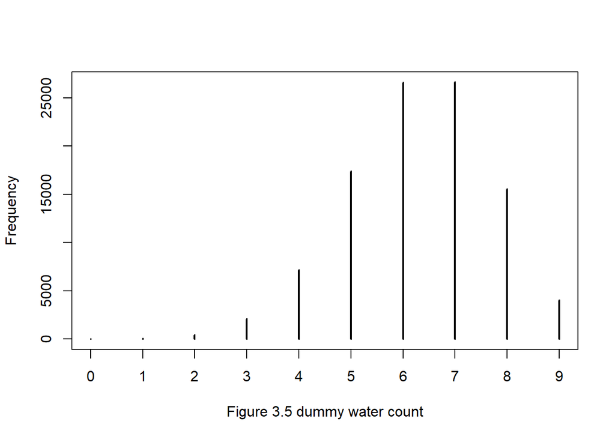

```r
dummy_w = rbinom(1e5, size = 9, prob = 0.7)
# library(rethinking)
simplehist(dummy_w, xlab = "Figure 3.5 dummy water count")
```

Figure 3.5から分かるように，$p=0.7$にならない割合（$6$回以下）の観測もかなりの数存在する。

## 3.3.2. モデルチェック

モデルチェックには以下のプロセスがある。

1. モデルフィットの正しさ
2. モデルの適切さ

ベイジアンモデルは常に生成的である。すなわち，パラメータ推定だけでなく観測シミュレーションもできる。

### 3.3.2.1. プログラムはうまく動いたか？

生成された予測とデータの対応をチェックする。完全一致は期待も望まれもしないが，全く対応していないと，プログラムの不具合も疑われる。プログラムが正しく動いたかを確かめる方法はない。解析的な結果と比較するのが端的な方法である。

### 3.3.2.2. モデルは適切か？

モデル予測でうまく記述できないデータの側面を調べることも重要である。全てのモデルは偽であるから，モデルの仮定が“真”であるかどうかをテストすることは目的にはならない。むしろモデルがデータ記述にどの程度失敗しているかを正確に評価することが目的となる。そのためには点推定量ではなく事後分布全体を使う方が良い。情報の損失は過信につながってしまう。

モデル予測には$2$種類の不確実さがつきまとう。第一に，地球儀問題において，パラメータ$p$が異なれば，モデルが予測する観察パターンも異なる。また，$p$が分かっていたとしても，次のトスの結果は分からない（$p=0$または$p=1$を除く）。第二に，$p$の不確実さであり，サンプリングの変動と関係する。

必要なことは各$p$に対する事後密度分布を集約することである。このプロセスで作られる分布は事後予測分布（posterior predictive distribution）と呼ばれる。

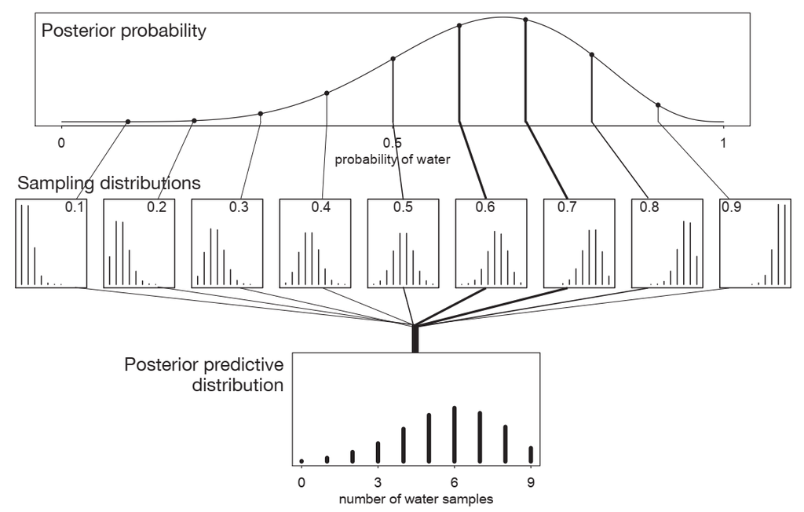

Figure 3.6

Figure 3.6はこの集約化を示している。事後確率を使って，中段にある各$p$に対する標本分布の重み付け平均を計算することで事後予測分布を得る。事後予測分布は事後分布に埋め込まれている不確実さを全て統合している。Figure 3.6の事後分布のピークになる単一のパラメータで予測を計算すると，過信になりやすい予測分布になりやすい。それに対して事後予測分布は各$p$に対する不確実さを考慮しているのでより誠実な（honest）分布と言える。 事後予測分布を直接得る前に，まずは具体的な$p$を設定して，予測での動作を確認しよう。

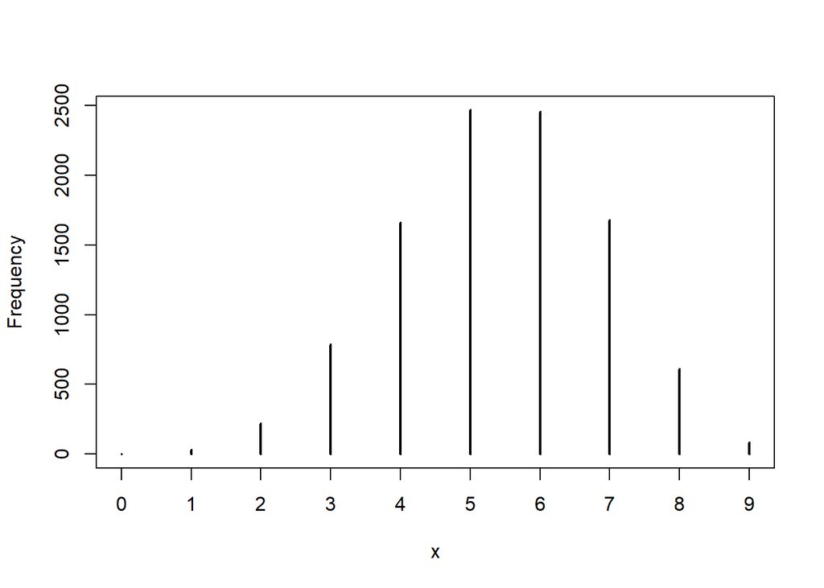

```r
w = rbinom(1e4, size = 9, prob = 0.6)
simplehist(w)
```

集約化のためには，上記プログラムの$0.6$を事後分布からのサンプルに置き換える。サンプルの値は事後確率に比例するので，シミュレーションデータは事後分布による重み付け平均になる。もう一度，セクション3.1の初めのスクリプトを実行し，Figure 3.6の事後分布を得て，そのサンプルを使えばFigure 3.6下段の事後予測分布が得られる。

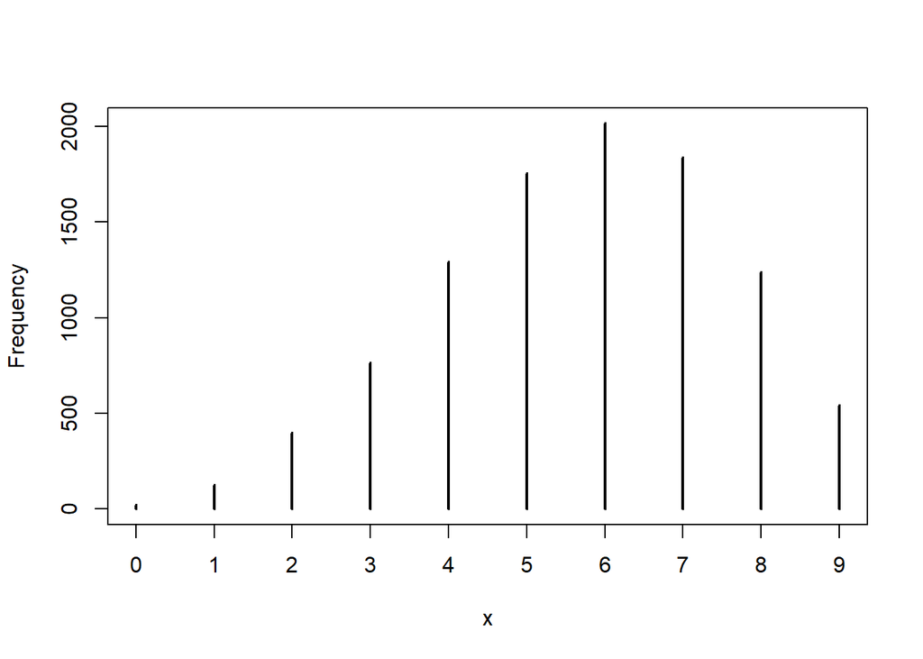

```r
p_grid = seq(from = 0, to = 1, length.out = 1000)
prior = rep(1 , 1000)
likelihood = dbinom(6, size = 9, prob = p_grid)
unstandardized.posterior = likelihood * prior
posterior = unstandardized.posterior / sum(unstandardized.posterior)
samples = sample(p_grid, prob = posterior, size = 1e4, replace = TRUE)

w = rbinom(1e4, size = 9, prob = samples)
simplehist(w)
```

モデルが失敗する予測の諸側面を探ろう。観察データの系列が「WLWWWLWLW」である時，相関（非独立性）に関する視点として，

1. 連続出現：Wが$3$回
2. 事象のスイッチ：$6$回

を考えることができる。Figure 3.7はこれら二つの視点でのシミュレーション予測である。

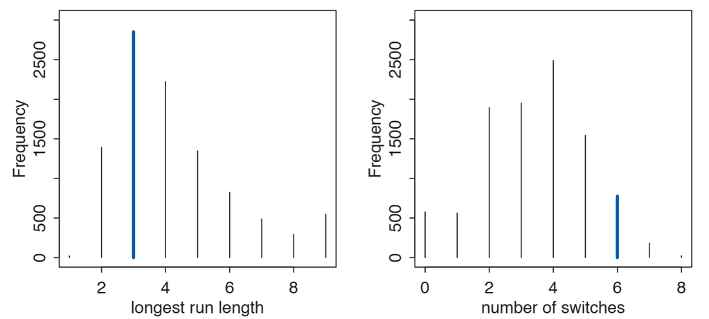

Figure 3.7

連続出現（Figure 3.7左）は「$3$回」が最も生じやすいという結果であり，これは観測データと一致する。一方，事象のスイッチについては，シミュレーション予測と観測データであまり一貫性がないように見える。これはトスの独立性が弱いことを示している。

このモデルが悪いかどうかという判断はケース・バイ・ケースである。もしスイッチが起こりやすいなら，トスは地球儀の海の割合についてはあまり情報を提供してくれないことになる。連続出現においては，誤ったモデルであっても正しい割合に収束していくと考えられる。

伝統的統計学の$p$値のように，観測データが予測分布の裾に位置していれば，モデルはあまり良くないと結論できるであろうか？ 統計の文脈は様々であるので，普遍的な解答はない。より重要なのは，“極端”の捉え方はたくさんあるということである。検定での$p$値はモデルチェックの非常に弱い形式である。モデルフィットと違い，モデルチェックは本質的には主観的であり，専門知識に依存する。主観と客観を協働させることが重要である。

# 3.4. まとめ

事後分布からのサンプリングが推論のための基本ツールである。これにより，積分ではなくデータ要約（区間推定，点推定，事後予測チェックなど）で検討できるようになる。

事後予測チェックは，事後分布で示されるパラメータの不確実さと尤度関数で示される結果の不確実さを集約したものである。モデルの不適切さを知るのに有用である。モデルが複雑になればなるほど，事後予測シミュレーションが役立つ。

# 3.5. 練習問題

> EASY

地球儀問題に関する事後分布からのサンプルデータsamplesを使用しなさい。

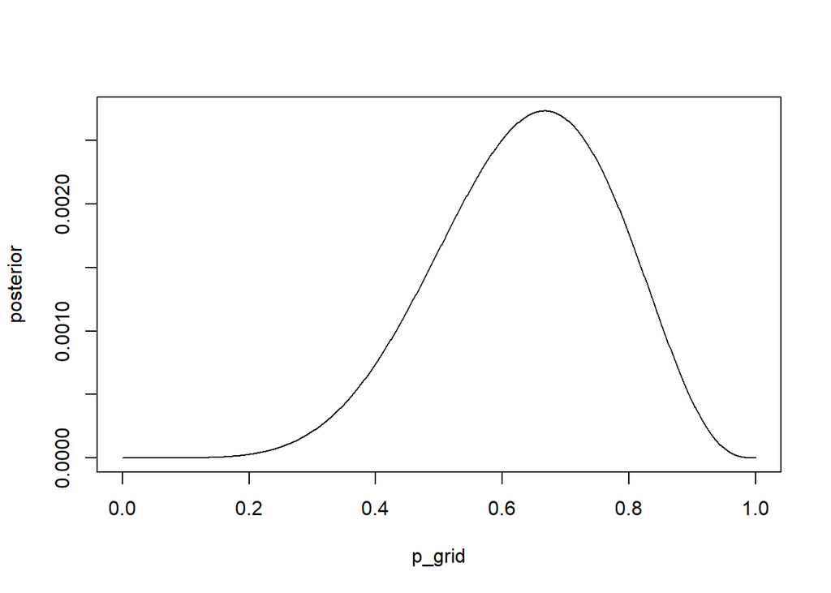

```r
p_grid = seq(from = 0, to = 1, length.out = 1000)
prior = rep(1, 1000)
likelihood = dbinom(6, size = 9, prob = p_grid)
unstandardized.posterior = likelihood * prior
posterior = unstandardized.posterior / sum(unstandardized.posterior)
set.seed(100)
samples = sample(p_grid, prob = posterior, size = 1e4, replace = TRUE)
plot(posterior ~ p_grid, type = "l")
```

##### 【3E1.】

$p=0.2$以下の事後確率はいくらか？

$0.0005$。

```r
mean(samples <= 0.2)
```

```
## [1] 5e-04
```

##### 【3E2.】

$p=0.8$以上の事後確率はいくらか？

```r
mean(samples <= 0.8)
```

```
## [1] 0.8883
```

##### 【3E3.】

$p=0.2$から$p=0.8$の間になる事後確率はいくらか？

$0.8878$。

```r
mean(samples >= 0.2 & samples <= 0.8)
```

```
## [1] 0.8878
```

##### 【3E4.】

下側事後確率が$20\%$となる$p$はいくつか？

$p = 0.5195195$。

```r
quantile(samples, p = 0.2)
```

```
##       20%
## 0.5195195
```

##### 【3E5.】

上側事後確率が$20\%$となる$p$はいくつか？

$p = 0.7567568$。

```r
quantile(samples, p = 1 - 0.2)
```

```
##       80%
## 0.7567568
```

##### 【3E6.】

事後確率が$66\%$となる最も狭い区間の$p$はいくつか？

最高事後密度区間$[0.5205205, 0.7847848]$。

```r
HPDI(samples, prob = 0.66)
```

```
##     |0.66     0.66|
## 0.5205205 0.7847848
```

##### 【3E7.】

事後確率が$66\%$となる区間で，その区間の上下の事後確率が等しくなる場合の$p$はいくつか？

$66\%$確信区間$[0.5005005, 0.7687688]$。

```r
quantile(samples, c(0.17, 0.66 + 0.17))
```

```
##       17%       83%
## 0.5005005 0.7687688
```

> MEDIUM

##### 【3M1.】

地球儀を$15$回トスしたところ，$8$回「海」となったとしよう。グリッド近似によって事後分布を求めなさい。事前確率として一様分布を用いなさい。

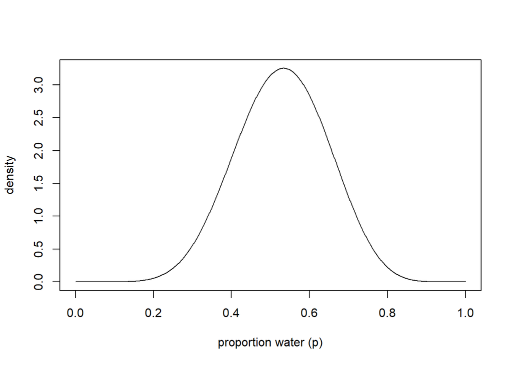

```r
p_grid = seq(from = 0, to = 1, length.out = 1000)
prior = rep(1, length(p_grid))
likelihood = dbinom(8, size = 15, prob = p_grid)
unstandardized.posterior = likelihood * prior
posterior = unstandardized.posterior / sum(unstandardized.posterior)
posterior = posterior * length(p_grid)    # 確率⇒確率密度に変換
plot(posterior ~ p_grid, type = "l", xlab = "proportion water (p)", ylab = "density")
```

##### 【3M2.】

前問のグリッド近似から$10,000$個サンプルを取り出しなさい。そのサンプルを使って，$90\%$HPDIを算出しなさい。

```r
samples = sample(p_grid, size = 1e4, replace = TRUE, prob = posterior)
# library(rethinking)
HPDI(samples, p = 0.9)
```

```
##      |0.9      0.9|
## 0.3383383 0.7317317
```

##### 【3M3.】

上記モデル及びでーたに対する事後予測チェックを構成しなさい。これは，$p$の事後不確実さを平均化しつつ，サンプルの分布をシミュレートする。$15$回のトスにおいて$8$回海となる確率はいくつか？

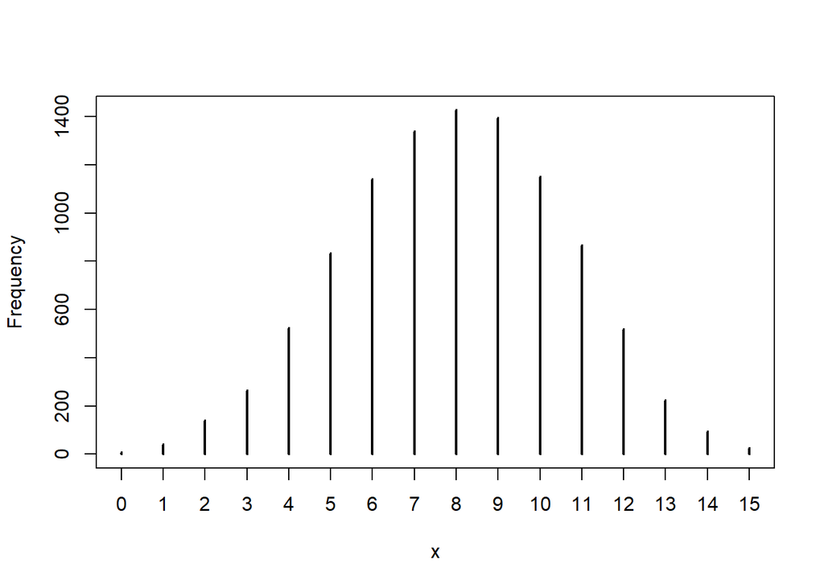

```r
posterior.predictive.distribution = rbinom(n = 1e4, size = 15, prob = samples)
# library(rethinking)
simplehist(posterior.predictive.distribution)
```

```r
mean(posterior.predictive.distribution == 8)
```

```
## [1] 0.1428
```

##### 【3M4.】

引き続きデータ（$8/15$）から構成した事後分布を使って，$9$回中$6$回海が観察される確率を計算しなさい。

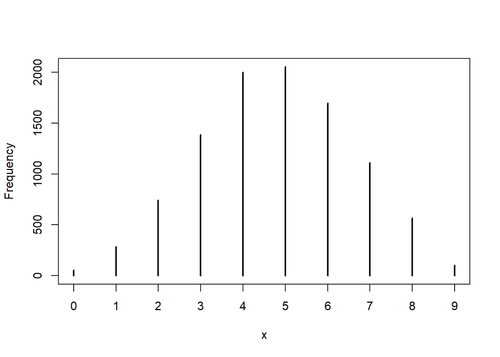

```r
posterior.predictive.distribution = rbinom(n = 1e4, size = 9, prob = samples)
simplehist(posterior.predictive.distribution)
```

```r
mean(posterior.predictive.distribution == 6)
```

```
## [1] 0.1695
```

##### 【3M5.】

3M1をやりなおすが，今度は$p\le0.5$が$0$で$p>0.5$で定数となる事前分布を用いる。これは「地球表面の大部分は海」という事前情報に対応する。上記の各問題を繰り返し，推論結果を比較しなさい。より良い事前分布にはどのような違いがあるか？ 真の値$p=0.7$と比較してみなさい。

###### 3M1.

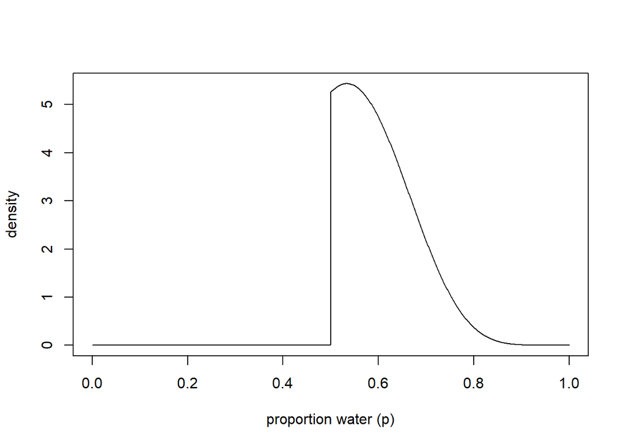

```r
p_grid = seq(from = 0, to = 1, length.out = 1000)
prior = ifelse(test = p_grid < .5, yes = 0, no = 1)   # 本来は規格化が必要
likelihood = dbinom(8, size = 15, prob = p_grid)
unstandardized.posterior = likelihood * prior
posterior = unstandardized.posterior / sum(unstandardized.posterior)
posterior = posterior * length(p_grid)    # 確率⇒確率密度に変換
plot(posterior ~ p_grid, type = "l", xlab = "proportion water (p)", ylab = "density")
```

$p<0.5$では確率密度は$0$となる。そのため，$p\ge 0.5$では概形は同じでも確率密度は高くなる。

###### 3M2.

```r
samples = sample(p_grid, size = 1e4, replace = TRUE, prob = posterior)
# library(rethinking)
HPDI(samples, p = 0.9)
```

```
##      |0.9      0.9|
## 0.5005005 0.7097097
```

有効な$p$が$0.5$以上に限定されていることにより，HPDIも$0.5$以上の範囲に変化した。

###### 3M3.

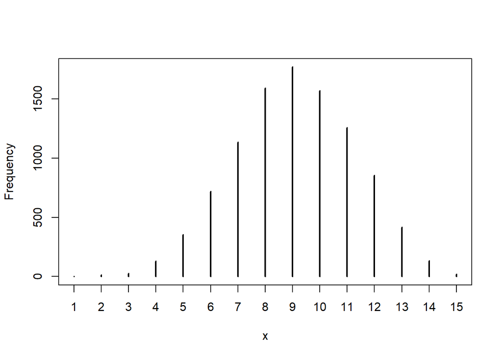

```r
posterior.predictive.distribution = rbinom(n = 1e4, size = 15, prob = samples)
# library(rethinking)
simplehist(posterior.predictive.distribution)
```

```r
mean(posterior.predictive.distribution == 8)
```

```
## [1] 0.1592
```

```r
pbinom(8, 15, prob = 0.7)
```

```
## [1] 0.1311426
```

###### 3M4.

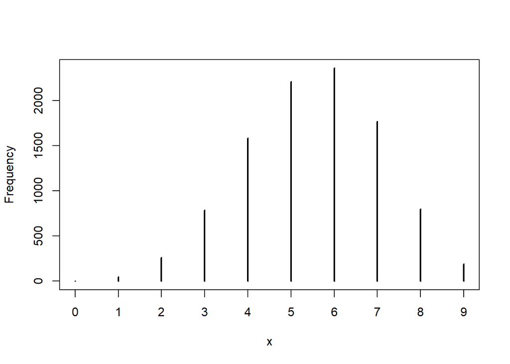

```r
posterior.predictive.distribution = rbinom(n = 1e4, size = 9, prob = samples)
# library(rethinking)
simplehist(posterior.predictive.distribution)
```

```r
mean(posterior.predictive.distribution == 6)
```

```
## [1] 0.2357
```

事後予測分布のモードが$5$から$6$に変化し，$9$回中$6$回海となる確率が大きくなった。$p=0.7$が真値だとした場合，この確率は$0.5371688$であるから，この変化は予測精度が上がっていることを示している。

```r
pbinom(6, 9, prob = 0.7)
```

```
## [1] 0.5371688
```

> HARD

ここでの練習問題では全て以下のデータを用いる。これらのデータは，$100$家族での第一子と第二子の性別を表している（男$=1$，女$=0$）。

```r
birth1 = c(1, 0, 0, 0, 1, 1, 0, 1, 0, 1, 0, 0, 1, 1, 0, 1, 1, 0, 0, 0, 1, 0, 0, 0, 1,
           0, 0, 0, 0, 1, 1, 1, 0, 1, 0, 1, 1, 1, 0, 1, 0, 1, 1, 0, 1, 0, 0, 1, 1, 0,
           1, 0, 0, 0, 0, 0, 0, 0, 1, 1, 0, 1, 0, 0, 1, 0, 0, 0, 1, 0, 0, 1, 1, 1, 1,
           0, 1, 0, 1, 1, 1, 1, 1, 0, 0, 1, 0, 1, 1, 0, 1, 0, 1, 1, 1, 0, 1, 1, 1, 1)
birth2 = c(0, 1, 0, 1, 0, 1, 1, 1, 0, 0, 1, 1, 1, 1, 1, 0, 0, 1, 1, 1, 0, 0, 1, 1, 1,
           0, 1, 1, 1, 0, 1, 1, 1, 0, 1, 0, 0, 1, 1, 1, 1, 0, 0, 1, 0, 1, 1, 1, 1, 1,
           1, 1, 1, 1, 1, 1, 1, 1, 1, 1, 1, 0, 1, 1, 0, 1, 1, 0, 1, 1, 1, 0, 0, 0, 0,
           0, 0, 1, 0, 0, 0, 1, 1, 0, 0, 1, 0, 0, 1, 1, 0, 0, 0, 1, 1, 1, 0, 0, 0, 0)
```

例えば，最初の家族は男（$1$），女（$0$）の順，$2$番目の家族は女（$0$），男（$1$）の順と回答した。$3$番目の家族は二人とも女と回答した。これらのベクトルは次のようにしてもロードできる：

```r
library(rethinking)
data(homeworkch3)
```

これらベクトルをデータとして使いなさい。例えば，男の子の総計を計算するには次のようにすれば良い：

```r
sum(birth1) + sum(birth2)
```

```
## [1] 111
```

##### 【3H1.】

グリッド近似を使って，男の子が生まれる確率（事後分布）を計算しなさい。一様事前分布を仮定しなさい。パラメータが事後確率を最大にするパラメータはいくつか？

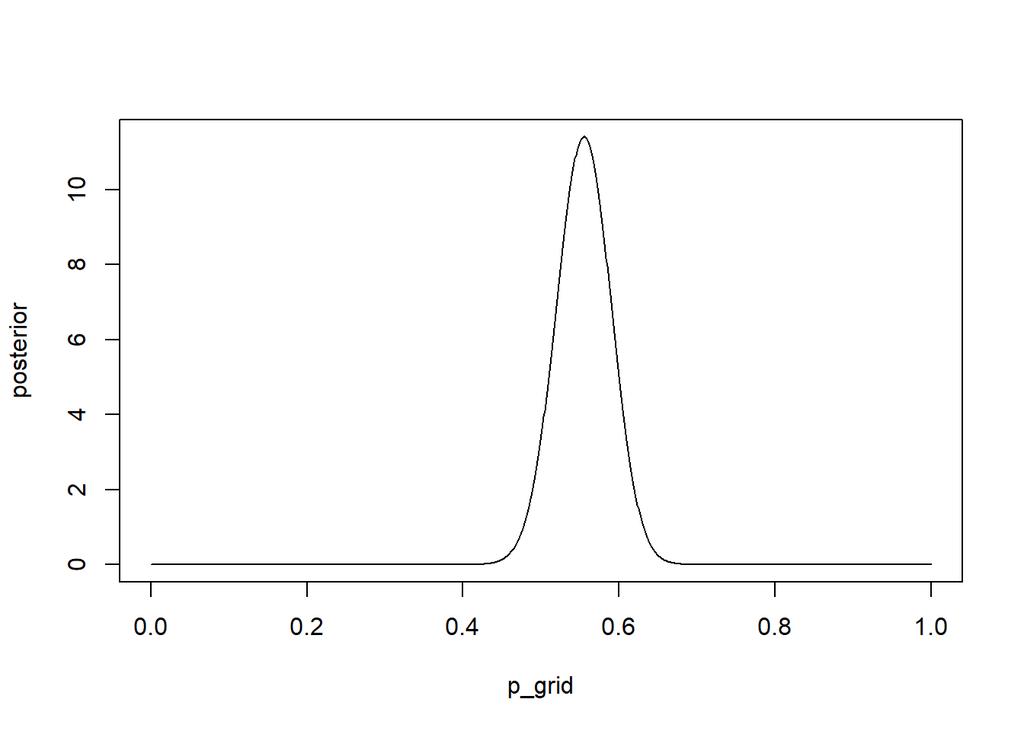

```r
total.births = length(birth1) + length(birth2)
boys.born = sum(birth1 + birth2)
girls.born = total.births - boys.born

p_grid = seq(from = 0, to = 1, length.out = 1000)
prior = rep(x = 1, length(p_grid))
likelihood = dbinom(x = boys.born, size = total.births, prob = p_grid)
unstandardized.posterior = likelihood * prior
posterior = unstandardized.posterior / sum(unstandardized.posterior)
posterior = posterior * length(p_grid)
plot(posterior ~ p_grid, type = "l")
```

```r
p_grid[which.max(posterior)]
```

```
## [1] 0.5545546
```

##### 【3H2.】

sample関数を使って，前問で計算した事後分布から$10,000$個のパラメータを取り出しなさい。これらのサンプルを使って，$50\%$，$89\%$，$97\%$の最高事後密度区間を求めなさい。

```r
samples = sample(p_grid, size = 1e4, prob = posterior, replace = TRUE)
HPDI(samples, prob = c(.5, .89, .97))
```

```
##     |0.97     |0.89      |0.5      0.5|     0.89|     0.97|
## 0.4764765 0.5015015 0.5255255 0.5725726 0.6116116 0.6286286
```

##### 【3H3.】

rbinom関数を使って，$200$の出産を$10,000$回シミュレートしなさい。これで，$200$人のうちの男の子の数を$10,000$個得ることになる。予測される男の子の数の分布と実測データ（$200$人中$111$人）と比較しなさい。シミュレーションの視覚化には様々な良い方法があるが，この場合はdens関数（rethinkingパッケージ）がおそらく最も簡単な方法である。モデルがデータにフィットしていそうか？ すなわち，予測分布は実測値を中心に含んでいるか？

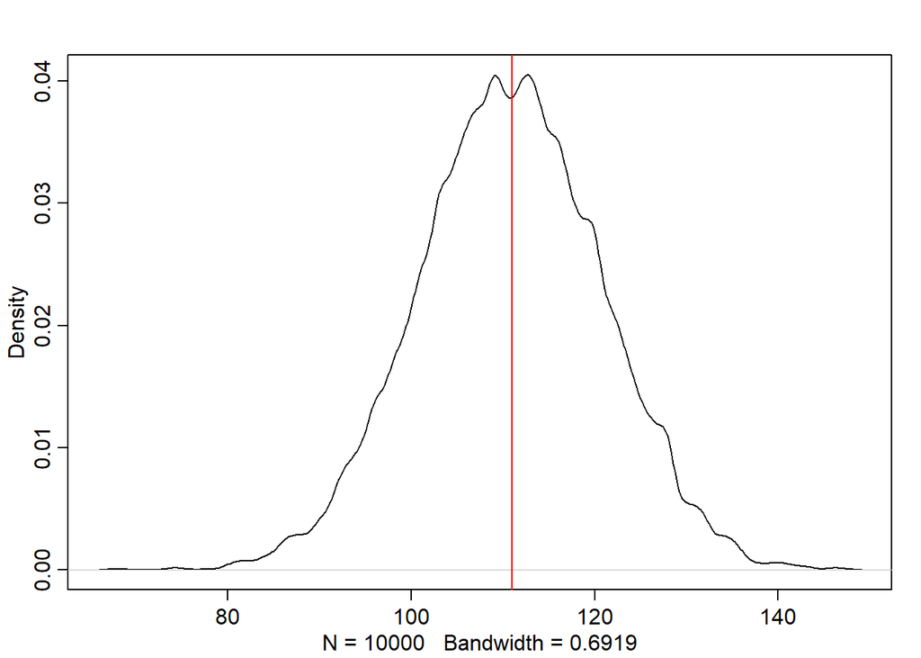

```r
posterior.predictive.distribution = rbinom(n = 1e4, size = total.births, prob = samples)
dens(posterior.predictive.distribution)
abline(v = boys.born, col = "red")
```

##### 【3H4.】

第一子$100$名のシミュレーションから男の子の数$10,000$個と，第一子実測データbirth1の男の子の数を比較しなさい。モデルの様子はどうだろうか？

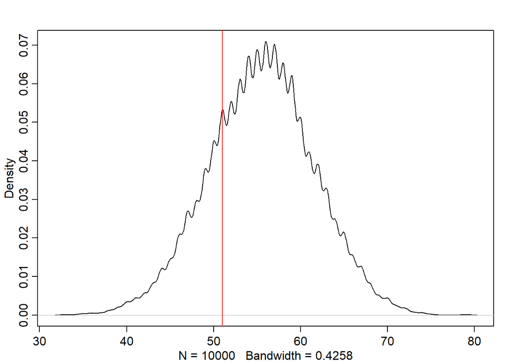

```r
posterior.predictive.distribution = rbinom(n = 1e4, size = 100, prob = samples)
dens(posterior.predictive.distribution)
abline(v = sum(birth1), col = "red" )
```

##### 【3H5.】

モデルは第一子と第二子の性別は独立していると仮定している。この仮定をチェックするために，第一子が女の子に続く第二子に着目しなさい。シミュレーションでの男の子の数と，女の子に続く第二子の男の子の数を比較しなさい。正しく実行するためには，第一子が女の子である数を数え，$10000$回シミュレーションする必要がある。シミュレーションでの男の子の数と，女の子に続く男の子の実測数を比較しなさい。モデルの様子はどうだろうか？ 以上のデータから何が推測されるか？

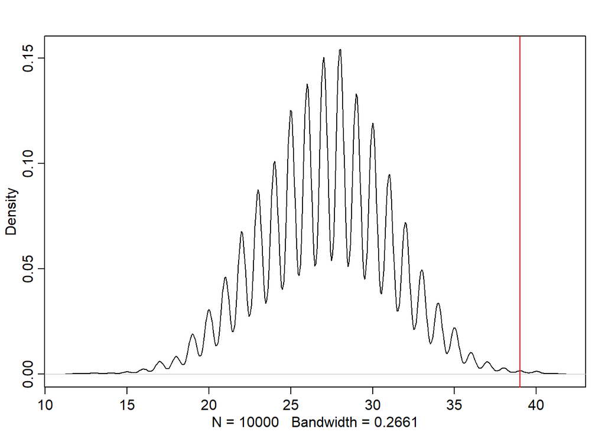

```r
boys.born.after.girls = birth2[birth1 == 0]
posterior.predictive.distribution = rbinom(n = 1e4, size = length(boys.born.after.girls), prob = samples)
dens(posterior.predictive.distribution)
abline(v = sum(boys.born.after.girls), col = "red")
```

事後予測分布の中央付近に実測値が位置しないので，第一子と第二子の性別は独立とは言えないと考えられる。